# marginalization of routine inflammatory parameters data on age and sex

The Goal of this notebook is to test for significant different between subgroups (controls, I, II ,III) for each of the routine inflammatory parameters.

The results are represented in the form of boxplots, which appear in supplementary Figure 2 A.

We use the marginalization data wherever it is relevant ;ie, when the marginalization model's assumption were satisfactorily respected (see marginalization notebook)

## TOC

1. preliminary definitions

2. reading the data

3. boxplots

- 3.1. glucose ratio
- 3.2. Lactate
- 3.3 Albumin ratio
- 3.4 protein
- 3.5 leukocytes
- 3.6 glucose

## 1. preliminary definitions

```python
import numpy as np
import pandas as pd
import matplotlib.pyplot as plt
import seaborn as sns
import scipy.stats as stats

palette5 = {'III' :'#073B4C',
    'II' : '#118AB2',
       'I' : '#06D6A0',
    'healthy control' : '#FFCE5C',
    'CNS inflammatory' : '#F26989' }
```

```python
from statsmodels.stats.multitest import multipletests

order5 = ['healthy control' , "I" , "II" , 'III' , 'CNS inflammatory']

contrasts = []
for i,g1 in enumerate(order5):
    for j,g2 in enumerate(order5):
        if j<=i:
            continue
        contrasts.append( (g1,g2) )


group2position = { g:i for i,g in enumerate(order5)}
```

```python
def contrastMWU( data , groupCol , testCol , contrasts = contrasts):
    """ performs exact MWU test for a set of pairs of groups,
    corrects pvalues using BH procedure.
    Report results as dictionnary """

    resD = {'contrast':[],
        'pval':[],
        'N1':[],
        'N2':[],
        'Median1':[],
        'Median2':[]}

    for contrast in contrasts:
        mC1 = data[groupCol] == contrast[0]
        mC2 = data[groupCol] == contrast[1]

        nN = ~data[testCol].isna()
        X1 = data.loc[ nN&mC1 , testCol ]
        X2 = data.loc[ nN&mC2 , testCol ]

        s,pval = stats.mannwhitneyu(X1,X2, method='exact')

        resD['contrast'].append( contrast )
        resD['pval'].append( pval )
        resD['N1'].append( len(X1) )
        resD['N2'].append( len(X2) )
        resD['Median1'].append( X1.median() )
        resD['Median2'].append( X2.median() )

    reject , pval_corrected , alpha1, aplha2 = multipletests( resD['pval'] ,
                                                             alpha = 0.05 , method = 'fdr_bh' , is_sorted=False)

    resD['padj'] = pval_corrected
    return resD
```

```python
def makeMolecPanel( data , molecName , ax , WH , ylabSize=20 , xtick_fontsize=16 , title_size=25  ):
    """function specific to the immunoglobulin plots.
        Returns a dictionnary with the MWU test results"""

    ## special colors for specific points
    data['color'] = 'grey'
    data.loc[ ['C15','C23','C40'] ,'color'] = 'red'
    if molecName.endswith('IgG'):
        data.loc[ ['C39'] ,'color'] = 'orange'
    elif molecName.endswith('IgA'):
        data.loc[ ['C19','C26','C39'] ,'color'] = 'orange'


    #ax.axhline(0 , color='grey')
    sns.boxplot( x="stageGroup" , y = 'Average' , data=data ,
                     order = order5 , palette = palette5 , ax =ax ,  showfliers = False )
    sns.stripplot( x="stageGroup" , y = 'Average' , data=data ,
                     order = order5 , hue= "color" ,
                  palette = ['grey','red','orange'] , hue_order=['grey','red','orange'] ,
                  ax =ax , size= 10*WH/10)

    ax.legend([],[], frameon=False)
    ax.set_xlabel( 'class' ,fontname = 'Arial' , size = ylabSize)
    ax.set_ylabel( 'ΔOD450' ,fontname = 'Arial' , size = ylabSize)
    ax.set_xticks([group2position[x] for x in order5],
                  [x.replace(' ','\n') for x in order5],
                  fontname = 'Arial' , fontsize= xtick_fontsize )
    ax.set_title( molecName.replace('_',' ') , fontname = 'Arial' , size=title_size)

    ax.xaxis.grid() # vertical lines
    interLevelScale= 0.01

    MWU_results = contrastMWU( data , groupCol='stageGroup' , testCol='Average' , contrasts = contrasts)

    MWUpval_cor = { MWU_results['contrast'][i]:MWU_results['padj'][i] for i in range(len(MWU_results['contrast'])) }

    ## create the bracket
    m = data['Average'].min()
    M = data['Average'].max()

    level=1
    for i,contrast in enumerate(contrasts):

        if MWUpval_cor[ contrast ]>=0.05:
            continue ## ignore non-sig tests

        ## get significance:
        padj = MWUpval_cor[ contrast ]
        symbol = 'NS'
        bracketColor = 'grey'
        if padj <0.05:
            bracketColor='black'
            if padj>=0.01:
                symbol = '*'
            else:
                symbol = '*' * -int( np.log10(padj) )

        x1 = group2position[ contrast[0] ]
        x2 = group2position[ contrast[1] ]


        step = max( (M-m) * 14/1000 * WH*0.95  , interLevelScale * M)
        #print(step)
        y = M + (step * level )
        yp = M + (step * (level - 0.25) )
        #print( x1,x2 , y )

        ax.plot( [x1,x1,x2,x2] , [yp,y,y,yp] , color=bracketColor )
        ax.text( (x1+x2)*0.5 , y , symbol , font ='monospace' , fontsize = 14 , color = bracketColor)
        level += 1
    return MWU_results
```

toc

## 2. reading the data

fig2A contains routine clinical measurements.

Each part are fairly different (different scales, ...), so le'ts proceed step by step

```python
df_marginal = pd.read_csv("supDocs/data_clinical_measurements_marginalized.csv",index_col=0)
df_marginal.stageGroup.value_counts()
```

```
healthy control     25
CNS inflammatory    25
I                   18
III                 15
II                   7
Name: stageGroup, dtype: int64
```

```python
df_raw = pd.read_csv("supDocs/data_clinical_measurements.csv",index_col=0)
df_raw.Stage.value_counts()
```

```
healthy control     25
CNS inflammatory    25
I                   18
III                 15
II                   7
Name: Stage, dtype: int64
```

toc

## 3. boxplots

### 3.1. glucose ratio

rather than purely glucose we have to get CSF/plasma glucose ratio for all patients

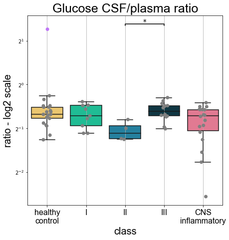

```python
data=df_marginal
molecName='CSF_plasma_glucose_ratio'
ax
WH=7
ylabSize=20
xtick_fontsize=16
title_size=25

fig,ax = plt.subplots(figsize=(1*WH,WH))

## special colors for specific points
outColor = 'xkcd:light purple'
data['color'] = 'grey'
data.loc[ ['5904'] ,'color'] = outColor


#ax.axhline(0 , color='grey')
sns.boxplot( x="stageGroup" , y = molecName , data=data ,
                 order = order5 , palette = palette5 , ax =ax ,  showfliers = False )
sns.stripplot( x="stageGroup" , y = molecName , data=data ,
                 order = order5 , hue= "color" ,
              palette = ['grey',outColor] , hue_order=['grey',outColor] ,
              ax =ax , size= 10*WH/10)

ax.legend([],[], frameon=False)
ax.set_xlabel( 'class' ,fontname = 'Arial' , size = ylabSize)
ax.set_ylabel( 'ratio - log2 scale' ,fontname = 'Arial' , size = ylabSize)
ax.set_xticks([group2position[x] for x in order5],
              [x.replace(' ','\n') for x in order5],
              fontname = 'Arial' , fontsize= xtick_fontsize )
ax.set_title( 'Glucose CSF/plasma ratio' , fontname = 'Arial' , size=title_size)
ax.set_yscale('log',base=2)

ax.xaxis.grid() # vertical lines

interLevelScale= 0.01

MWU_results = contrastMWU( data , groupCol='stageGroup' , testCol=molecName , contrasts = contrasts)

MWUpval_cor = { MWU_results['contrast'][i]:MWU_results['padj'][i] for i in range(len(MWU_results['contrast'])) }

## create the bracket
m = data[molecName].min()
M = data[molecName].max()

level=1
for i,contrast in enumerate(contrasts):

    if MWUpval_cor[ contrast ]>=0.05:
        continue ## ignore non-sig tests

    ## get significance:
    padj = MWUpval_cor[ contrast ]
    symbol = 'NS'
    bracketColor = 'grey'
    if padj <0.05:
        bracketColor='black'
        if padj>=0.01:
            symbol = '*'
        else:
            symbol = '*' * -int( np.log10(padj) )

    x1 = group2position[ contrast[0] ]
    x2 = group2position[ contrast[1] ]


    step = max( (M-m) * 14/1000 * WH*0.95  , interLevelScale * M)
    #print(step)
    y = M + (step * level )
    yp = M + (step * (level - 0.25) )
    #print( x1,x2 , y )

    ax.plot( [x1,x1,x2,x2] , [yp,y,y,yp] , color=bracketColor )
    ax.text( (x1+x2)*0.5 , y , symbol , ha='center', font ='monospace' , fontsize = 14 , color = bracketColor)
    level += 1

## annotating the point excluded:
# ax.annotate("point excluded\nfrom marginalization\nmodel",
#     xy=( 0 , data.loc[ '5904' ,  molecName ] ),xycoords='data',
#     xytext=(0.3, 1.5) , textcoords='data',
#     arrowprops=dict(facecolor='black', arrowstyle='->', relpos=(0,1.0)))


fig.savefig('Fig2A/parts/'+molecName+'.pdf')
```

```python
## keep the results
MWU_results['molecule'] = [molecName]*len(MWU_results['padj'])
MWU_results['note'] = ['marginalized']*len(MWU_results['padj'])

clinical_MWU = defaultdict(list)
for k in MWU_results :
    clinical_MWU[k].extend( MWU_results[k] )
```

toc

## 3.2. Lactate

about the marginalization :

- patient NC040 was skewing the fit so it was excluded from the model (the data point remains, we only prevented it to skew the marginalization)
- the data was log10-transformed to avoid heteroskedascticity

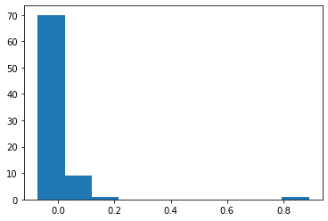

```python
#difference between the log and non log marginalization
plt.hist( df_marginal['CSF_lactate'] - np.power(10 , df_marginal['CSF_lactate_log'] ) )
```

```python
df_marginal['CSF_lactate_delog'] = np.power(10 , df_marginal['CSF_lactate_log'] )
## for plotting, let's get in the original space
## it looks nicer and is easier to interpret
```

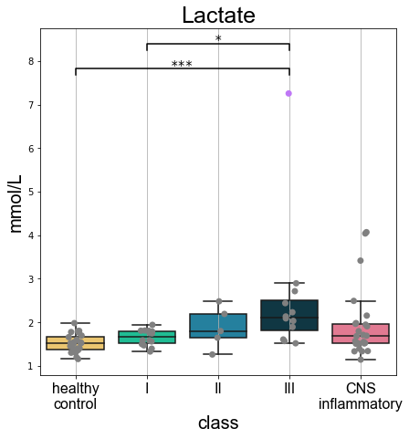

```python
data=df_marginal
molecName='CSF_lactate_delog'

WH=7
ylabSize=20
xtick_fontsize=16
title_size=25

fig,ax = plt.subplots(figsize=(1*WH,WH))

## special colors for specific points
outColor = 'xkcd:light purple'
data['color'] = 'grey'
data.loc[ ['NC040'] ,'color'] = outColor


#ax.axhline(0 , color='grey')
sns.boxplot( x="stageGroup" , y = molecName , data=data ,
                 order = order5 , palette = palette5 , ax =ax ,  showfliers = False )
sns.stripplot( x="stageGroup" , y = molecName , data=data ,
                 order = order5 , hue= "color" ,
              palette = ['grey',outColor] , hue_order=['grey',outColor] ,
              ax =ax , size= 10*WH/10)

ax.legend([],[], frameon=False)
ax.set_xlabel( 'class' ,fontname = 'Arial' , size = ylabSize)
ax.set_ylabel( 'mmol/L' ,fontname = 'Arial' , size = ylabSize)
ax.set_xticks([group2position[x] for x in order5],
              [x.replace(' ','\n') for x in order5],
              fontname = 'Arial' , fontsize= xtick_fontsize )
ax.set_title( 'Lactate' , fontname = 'Arial' , size=title_size)

ax.xaxis.grid() # vertical lines

interLevelScale= 0.01

MWU_results = contrastMWU( data , groupCol='stageGroup' , testCol=molecName , contrasts = contrasts)

MWUpval_cor = { MWU_results['contrast'][i]:MWU_results['padj'][i] for i in range(len(MWU_results['contrast'])) }

## create the bracket
m = data[molecName].min()
M = data[molecName].max()

level=1
for i,contrast in enumerate(contrasts):

    if MWUpval_cor[ contrast ]>=0.05:
        continue ## ignore non-sig tests

    ## get significance:
    padj = MWUpval_cor[ contrast ]
    symbol = 'NS'
    bracketColor = 'grey'
    if padj <0.05:
        bracketColor='black'
        if padj>=0.01:
            symbol = '*'
        else:
            symbol = '*' * -int( np.log10(padj) )

    x1 = group2position[ contrast[0] ]
    x2 = group2position[ contrast[1] ]


    step = max( (M-m) * 14/1000 * WH*0.95  , interLevelScale * M)
    #print(step)
    y = M + (step * level )
    yp = M + (step * (level - 0.25) )
    #print( x1,x2 , y )

    ax.plot( [x1,x1,x2,x2] , [yp,y,y,yp] , color=bracketColor )
    ax.text( (x1+x2)*0.5 , y , symbol ,ha='center', font ='monospace' , fontsize = 14 , color = bracketColor)
    level += 1

## annotating the point excluded:
# ax.annotate("point excluded\nfrom marginalization\nmodel",
#     xy=( 3 , data.loc[ 'NC040' ,  molecName ] ),xycoords='data',
#     xytext=(1, 6) , textcoords='data',
#     arrowprops=dict(facecolor='black', arrowstyle='->', relpos=(0.7,1)))


fig.savefig('Fig2A/parts/'+'CSF_lactate'+'.pdf')
```

```python
## keep the results
MWU_results['molecule'] = ['CSF_lactate']*len(MWU_results['padj'])
MWU_results['note'] = ['marginalized on log10-transform']*len(MWU_results['padj'])
for k in clinical_MWU :
    clinical_MWU[k].extend( MWU_results[k] )
```

toc

### 3.3 Albumin ratio

For the marginalization, the data was log10-transformed to avoid heteroskedascticity

```python
df_marginal.columns
```

```
Index(['CSF_leukocytes', 'CSF_lactate', 'CSF_protein',
       'CSF_blood_albumin_ratio', 'CSF_glucose', 'CSF_leukocytes_log',
       'CSF_protein_log', 'CSF_blood_albumin_ratio_log', 'CSF_lactate_log',
       'stageGroup', 'CSF_plasma_glucose_ratio', 'color', 'CSF_lactate_delog'],
      dtype='object')
```

```python
df_marginal['CSF_blood_albumin_ratio_delog'] = np.power(10 , df_marginal['CSF_blood_albumin_ratio_log'] )
## for plotting, let's get in the original space
## it looks nicer and is easier to interpret
```

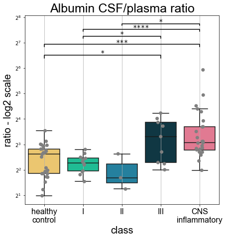

```python
data=df_marginal
molecName='CSF_blood_albumin_ratio_delog'

WH=7
ylabSize=20
xtick_fontsize=16
title_size=25

fig,ax = plt.subplots(figsize=(1*WH,WH))

## special colors for specific points
outColor = 'xkcd:light purple'
data['color'] = 'grey'
# no outlier


#ax.axhline(0 , color='grey')
sns.boxplot( x="stageGroup" , y = molecName , data=data ,
                 order = order5 , palette = palette5 , ax =ax ,  showfliers = False )
sns.stripplot( x="stageGroup" , y = molecName , data=data ,
                 order = order5 , hue= "color" ,
              palette = ['grey',outColor] , hue_order=['grey',outColor] ,
              ax =ax , size= 10*WH/10)

ax.legend([],[], frameon=False)
ax.set_xlabel( 'class' ,fontname = 'Arial' , size = ylabSize)
ax.set_ylabel( 'ratio - log2 scale' ,fontname = 'Arial' , size = ylabSize)
ax.set_xticks([group2position[x] for x in order5],
              [x.replace(' ','\n') for x in order5],
              fontname = 'Arial' , fontsize= xtick_fontsize )
ax.set_title( 'Albumin CSF/plasma ratio' , fontname = 'Arial' , size=title_size)
ax.set_yscale('log',base=2)
ax.xaxis.grid() # vertical lines

interLevelScale= 0.5

MWU_results = contrastMWU( data , groupCol='stageGroup' , testCol=molecName , contrasts = contrasts)

MWUpval_cor = { MWU_results['contrast'][i]:MWU_results['padj'][i] for i in range(len(MWU_results['contrast'])) }

## create the bracket
m = data[molecName].min()
M = data[molecName].max()

level=1
for i,contrast in enumerate(contrasts):

    if MWUpval_cor[ contrast ]>=0.05:
        continue ## ignore non-sig tests

    ## get significance:
    padj = MWUpval_cor[ contrast ]
    symbol = 'NS'
    bracketColor = 'grey'
    if padj <0.05:
        bracketColor='black'
        if padj>=0.01:
            symbol = '*'
        else:
            symbol = '*' * -int( np.log10(padj) )

    x1 = group2position[ contrast[0] ]
    x2 = group2position[ contrast[1] ]


    step = max( (M-m) * 14/1000 * WH*0.95  , interLevelScale * M)
    #print(step)
    y = M + (step * level )
    yp = M + (step * (level - 0.25) )
    #print( x1,x2 , y )

    ax.plot( [x1,x1,x2,x2] , [yp,y,y,yp] , color=bracketColor )
    ax.text( (x1+x2)*0.5 , y , symbol , ha='center',font ='monospace' , fontsize = 14 , color = bracketColor)
    level += 1

## annotating the point excluded:


fig.savefig('Fig2A/parts/'+'CSF_blood_albumin_ratio'+'.pdf')
```

```python
## keep the results
MWU_results['molecule'] = ['CSF_blood_albumin_ratio']*len(MWU_results['padj'])
MWU_results['note'] = ['marginalized on log10-transform']*len(MWU_results['padj'])
for k in clinical_MWU :
    clinical_MWU[k].extend( MWU_results[k] )
```

toc

## 3.4 protein

Regarding the marginalization:

- patient NC040 was skewing the fit so it was excluded from the model
- the data was log10-transformed to avoid heteroskedascticity

```python
df_marginal['CSF_protein_delog'] = np.power(10 , df_marginal['CSF_protein_log'] )
## for plotting, let's get in the original space
## it looks nicer and is easier to interpret
```

```
1.3
1.3
1.3
1.3
1.3
1.3
```

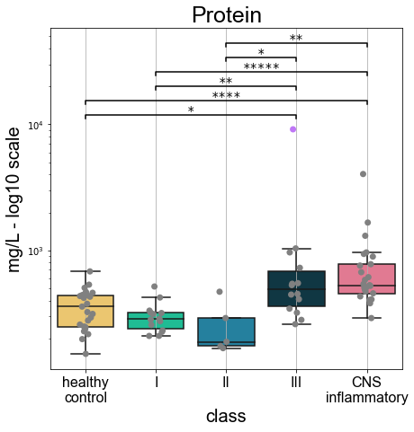

```python
data=df_marginal
molecName='CSF_protein_delog'

WH=7
ylabSize=20
xtick_fontsize=16
title_size=25

fig,ax = plt.subplots(figsize=(1*WH,WH))

## special colors for specific points
outColor = 'xkcd:light purple'
data['color'] = 'grey'
data.loc[ ['NC040'] ,'color'] = outColor


#ax.axhline(0 , color='grey')
sns.boxplot( x="stageGroup" , y = molecName , data=data ,
                 order = order5 , palette = palette5 , ax =ax ,  showfliers = False )
sns.stripplot( x="stageGroup" , y = molecName , data=data ,
                 order = order5 , hue= "color" ,
              palette = ['grey',outColor] , hue_order=['grey',outColor] ,
              ax =ax , size= 10*WH/10)

ax.legend([],[], frameon=False)
ax.set_xlabel( 'class' ,fontname = 'Arial' , size = ylabSize)
ax.set_ylabel( 'mg/L - log10 scale' ,fontname = 'Arial' , size = ylabSize)
ax.set_xticks([group2position[x] for x in order5],
              [x.replace(' ','\n') for x in order5],
              fontname = 'Arial' , fontsize= xtick_fontsize )
ax.set_title( 'Protein' , fontname = 'Arial' , size=title_size)
ax.set_yscale('log')
ax.xaxis.grid() # vertical lines

interLevelScale= 0.8

MWU_results = contrastMWU( data , groupCol='stageGroup' , testCol=molecName , contrasts = contrasts)

MWUpval_cor = { MWU_results['contrast'][i]:MWU_results['padj'][i] for i in range(len(MWU_results['contrast'])) }

## create the bracket
m = data[molecName].min()
M = data[molecName].max()

level=1
for i,contrast in enumerate(contrasts):

    if MWUpval_cor[ contrast ]>=0.05:
        continue ## ignore non-sig tests

    ## get significance:
    padj = MWUpval_cor[ contrast ]
    symbol = 'NS'
    bracketColor = 'grey'
    if padj <0.05:
        bracketColor='black'
        if padj>=0.01:
            symbol = '*'
        else:
            symbol = '*' * -int( np.log10(padj) )

    x1 = group2position[ contrast[0] ]
    x2 = group2position[ contrast[1] ]

    #step = max( (M/m) * 14/1000 * WH*0.95  , interLevelScale * M)
    step= 1.3#np.log10(  M/max(m,0.1))*0.5 # * 14/1000 * WH*0.95
    print(step)
    y = M * ((step ** level ))
    yp = M * ((step ** (level - 0.25) ))
    ax.plot( [x1,x1,x2,x2] , [yp,y,y,yp] , color=bracketColor )
    ax.text( (x1+x2)*0.5 , y , symbol ,ha='center', font ='monospace' , fontsize = 14 , color = bracketColor)
    level += 1



fig.savefig('Fig2A/parts/'+'CSF_protein'+'.pdf')
```

```python
## keep the results
MWU_results['molecule'] = ['CSF_protein']*len(MWU_results['padj'])
MWU_results['note'] = ['marginalized on log10-transform']*len(MWU_results['padj'])
for k in clinical_MWU :
    clinical_MWU[k].extend( MWU_results[k] )
```

toc

### 3.5 leukocytes

we recommend **not using the marginalized data** here, and being very careful about conclusions. Nevertheless keeping the log10 transform looks like a good idea (at least for data representations)

```python
## the point 5977 is very likely a rypo when entering data. let's exclude it
df_raw.loc['5977', 'CSF_leukocytes'] = np.nan
```

```
1.5
1.5
1.5
1.5
1.5
1.5
```

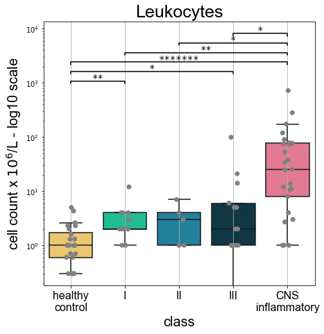

```python
data=df_raw
molecName='CSF_leukocytes'

WH=7
ylabSize=20
xtick_fontsize=16
title_size=25

fig,ax = plt.subplots(figsize=(1*WH,WH))

## special colors for specific points
outColor = 'xkcd:light purple'
data['color'] = 'grey'
# no outliers


#ax.axhline(0 , color='grey')
sns.boxplot( x="Stage" , y = molecName , data=data ,
                 order = order5 , palette = palette5 , ax =ax ,  showfliers = False )
sns.stripplot( x="Stage" , y = molecName , data=data ,
                 order = order5 , hue= "color" ,
              palette = ['grey',outColor] , hue_order=['grey',outColor] ,
              ax =ax , size= 10*WH/10)

ax.legend([],[], frameon=False)
ax.set_xlabel( 'class' ,fontname = 'Arial' , size = ylabSize)
ax.set_ylabel( r'cell count x $10^6$/L - log10 scale' ,fontname = 'Arial' , size = ylabSize)
ax.set_xticks([group2position[x] for x in order5],
              [x.replace(' ','\n') for x in order5],
              fontname = 'Arial' , fontsize= xtick_fontsize )
ax.set_title( 'Leukocytes' , fontname = 'Arial' , size=title_size)
ax.set_yscale('log')
ax.xaxis.grid() # vertical lines

interLevelScale= 0.8

MWU_results = contrastMWU( data , groupCol='Stage' , testCol=molecName , contrasts = contrasts)

MWUpval_cor = { MWU_results['contrast'][i]:MWU_results['padj'][i] for i in range(len(MWU_results['contrast'])) }

## create the bracket
m = data[molecName].min()
M = data[molecName].max()

level=1
for i,contrast in enumerate(contrasts):

    if MWUpval_cor[ contrast ]>=0.05:
        continue ## ignore non-sig tests

    ## get significance:
    padj = MWUpval_cor[ contrast ]
    symbol = 'NS'
    bracketColor = 'grey'
    if padj <0.05:
        bracketColor='black'
        if padj>=0.01:
            symbol = '*'
        else:
            symbol = '*' * -int( np.log10(padj) )

    x1 = group2position[ contrast[0] ]
    x2 = group2position[ contrast[1] ]

    #step = max( (M/m) * 14/1000 * WH*0.95  , interLevelScale * M)
    step= 1.5#np.log10(  M/max(m,0.1))*0.5 # * 14/1000 * WH*0.95
    print(step)
    y = M * ((step ** level ))
    yp = M * ((step ** (level - 0.25) ))
    ax.plot( [x1,x1,x2,x2] , [yp,y,y,yp] , color=bracketColor )
    ax.text( (x1+x2)*0.5 , y , symbol ,ha='center', font ='monospace' , fontsize = 14 , color = bracketColor)
    level += 1



fig.savefig('Fig2A/parts/'+'CSF_leukocytes'+'.pdf')
```

```python
## keep the results
MWU_results['molecule'] = ['CSF_leukocytes']*len(MWU_results['padj'])
MWU_results['note'] = ['raw - 5977 excluded']*len(MWU_results['padj'])
for k in clinical_MWU :
    clinical_MWU[k].extend( MWU_results[k] )
```

toc

### 3.6 glucose

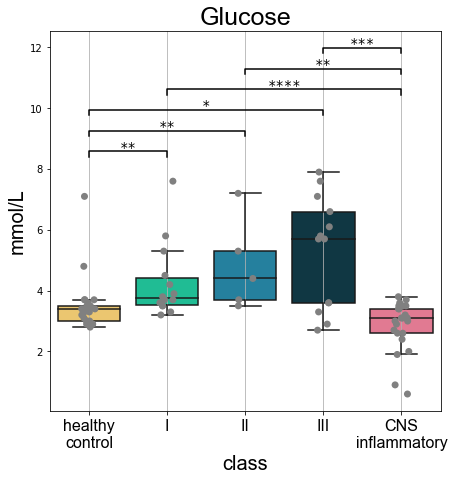

```python
data=df_raw
molecName='CSF_glucose'

WH=7
ylabSize=20
xtick_fontsize=16
title_size=25

fig,ax = plt.subplots(figsize=(1*WH,WH))

## special colors for specific points
outColor = 'xkcd:light purple'
data['color'] = 'grey'
# no outliers


#ax.axhline(0 , color='grey')
sns.boxplot( x="Stage" , y = molecName , data=data ,
                 order = order5 , palette = palette5 , ax =ax ,  showfliers = False )
sns.stripplot( x="Stage" , y = molecName , data=data ,
                 order = order5 , hue= "color" ,
              palette = ['grey',outColor] , hue_order=['grey',outColor] ,
              ax =ax , size= 10*WH/10)

ax.legend([],[], frameon=False)
ax.set_xlabel( 'class' ,fontname = 'Arial' , size = ylabSize)
ax.set_ylabel( 'mmol/L' ,fontname = 'Arial' , size = ylabSize)
ax.set_xticks([group2position[x] for x in order5],
              [x.replace(' ','\n') for x in order5],
              fontname = 'Arial' , fontsize= xtick_fontsize )
ax.set_title( 'Glucose' , fontname = 'Arial' , size=title_size)
#ax.set_yscale('log')
ax.xaxis.grid() # vertical lines

interLevelScale= 0.05

MWU_results = contrastMWU( data , groupCol='Stage' , testCol=molecName , contrasts = contrasts)

MWUpval_cor = { MWU_results['contrast'][i]:MWU_results['padj'][i] for i in range(len(MWU_results['contrast'])) }

## create the bracket
m = data[molecName].min()
M = data[molecName].max()

level=1
for i,contrast in enumerate(contrasts):

    if MWUpval_cor[ contrast ]>=0.05:
        continue ## ignore non-sig tests

    ## get significance:
    padj = MWUpval_cor[ contrast ]
    symbol = 'NS'
    bracketColor = 'grey'
    if padj <0.05:
        bracketColor='black'
        if padj>=0.01:
            symbol = '*'
        else:
            symbol = '*' * -int( np.log10(padj) )

    x1 = group2position[ contrast[0] ]
    x2 = group2position[ contrast[1] ]


    step = max( (M-m) * 14/1000 * WH*0.95  , interLevelScale * M)
    #print(step)
    y = M + (step * level )
    yp = M + (step * (level - 0.25) )
    #print( x1,x2 , y )

    ax.plot( [x1,x1,x2,x2] , [yp,y,y,yp] , color=bracketColor )
    ax.text( (x1+x2)*0.5 , y , symbol , ha='center',font ='monospace' , fontsize = 14 , color = bracketColor)
    level += 1


fig.savefig('Fig2A/parts/'+'CSF_glucose'+'.pdf')
```

```python
## keep the results
MWU_results['molecule'] = ['CSF_glucose']*len(MWU_results['padj'])
MWU_results['note'] = ['marginalized']*len(MWU_results['padj'])
for k in clinical_MWU :
    clinical_MWU[k].extend( MWU_results[k] )
```

```python
df_clinical_MWU = pd.DataFrame( clinical_MWU )
df_clinical_MWU.head()
```

|  | contrast | pval | N1 | N2 | Median1 | Median2 | padj | molecule | note |
| --- | --- | --- | --- | --- | --- | --- | --- | --- | --- |
| 0 | (healthy control, I) | 0.789869 | 21 | 9 | 0.623528 | 0.609555 | 0.789869 | CSF_plasma_glucose_ratio | marginalized |
| 1 | (healthy control, II) | 0.011225 | 21 | 4 | 0.623528 | 0.462642 | 0.056126 | CSF_plasma_glucose_ratio | marginalized |
| 2 | (healthy control, III) | 0.583210 | 21 | 14 | 0.623528 | 0.657006 | 0.648011 | CSF_plasma_glucose_ratio | marginalized |
| 3 | (healthy control, CNS inflammatory) | 0.212593 | 21 | 18 | 0.623528 | 0.609874 | 0.378218 | CSF_plasma_glucose_ratio | marginalized |
| 4 | (I, II) | 0.050350 | 9 | 4 | 0.609555 | 0.462642 | 0.162173 | CSF_plasma_glucose_ratio | marginalized |

```python
df_clinical_MWU.molecule.value_counts()
```

```
CSF_plasma_glucose_ratio    10
CSF_lactate                 10
CSF_blood_albumin_ratio     10
CSF_protein                 10
CSF_leukocytes              10
CSF_glucose                 10
Name: molecule, dtype: int64
```

```python
df_clinical_MWU.to_csv( 'supDocs/data_clinical_measurements_MWUcontrasts.csv' )
```